# Incarceration in the United States

Carson Klein

2/25/2022

**INFO-201: Technical Foundations of Informatics - The Information School - University of Washington**

### Introduction

The U.S. has long struggled with issues relating to racism, and with this data set, I believe there is an opportunity for a deeper dive into how racism connects to the jail/prison system in the U.S. To achieve this, I decided to focus my analysis around a few key variables:

- Race
- Region of the U.S.
- Jail Populations
- Prison Admissions
- ICE Incarcerations

These variables can give a good level of insight into some of the important concepts surrounding how racism is perpetuated in the U.S. Specifically, they can combine to tell us about how geography and race are intertwined with how the U.S. jail/prison system operates.

### Chart 1

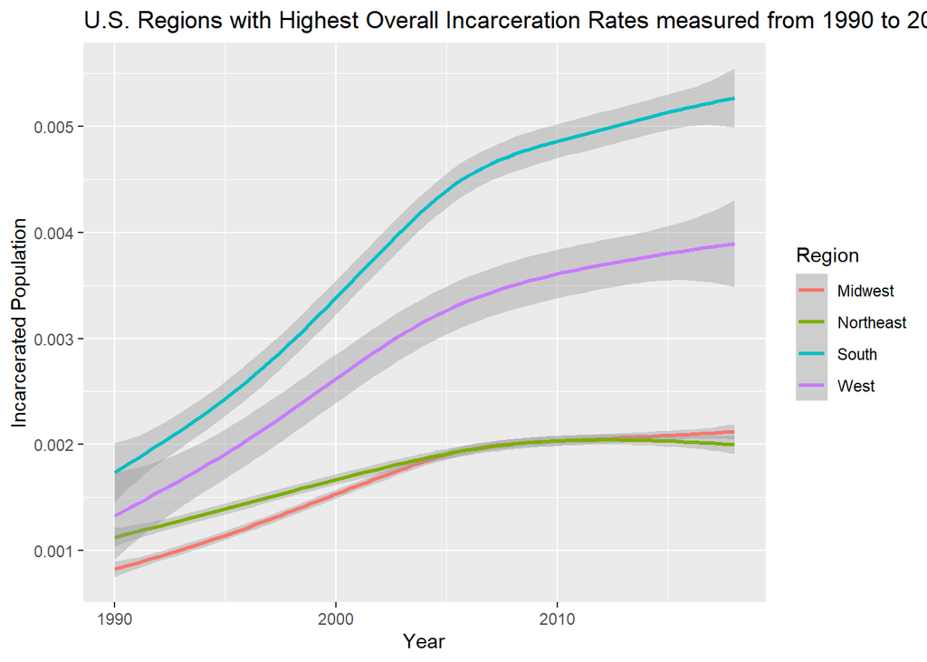

I included this chart to show how trends of incarceration can be mapped geographically over time to show in which regions the most people tend to be put in jail and prison. Specifically, the pattern of a greater number of incarcerations occurring in the Southern region of the U.S. is easily visible. This can mainly be attributed to the higher numbers of minority populations living in this region, such as higher Latino and Black populations, which are often targeted and over-policed, leading to these higher overall incarceration numbers in this region (and to a lesser extent the Western region).

### Chart 2

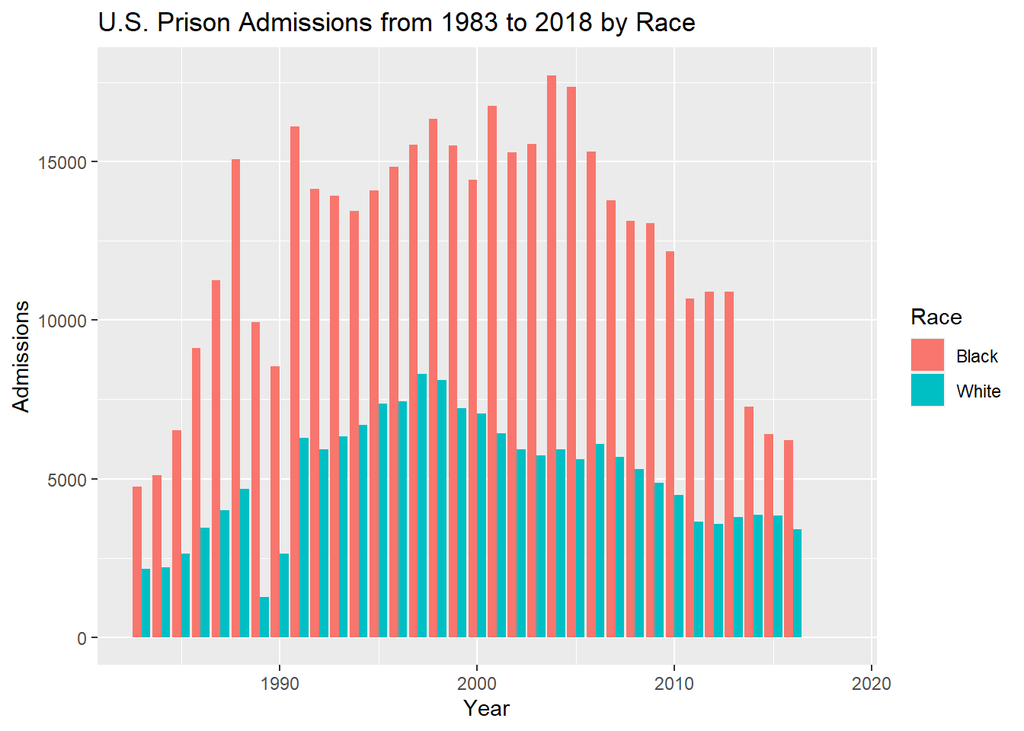

### Map

[interactive chart not shown]

This map acts as an expansion upon the first chart I included. It conveys a similar key idea, but does so in a way - and with different data - that conveys the actual scope of the issue, rather than answering the same questions as before. The bubbles shown on this map represent ICE-related incarcerations within each state, and it can clearly be seen which states have the most. Texas, Georgia, and Florida in the South, along with California in the West, and to a lesser extent, New Jersey and New York, represent areas with large amounts of immigration from Latin American countries (some legal and some illegal). Because of this, ICE are particularly active in these states, as they know many people immigrating have no other (realistic) choice but to immigrate illegally, which helps to show how racial disparities can often be intentionally perpetuated to the benefit of those running the prison system.